# Part I: Exploratory Data Analysis, Linear Regression, ANOVA

### Load Packages

First, we must load the packages that will be used in the first part of this workshop.

```r
library(pastecs, quietly = TRUE)
library(lm.beta,  quietly = TRUE)
library(lmtest,  quietly = TRUE)
library(foreign,  quietly = TRUE)
library(lattice,  quietly = TRUE)
library(lme4,  quietly = TRUE)
library(nlme,  quietly = TRUE)
library(survival,  quietly = TRUE)
library(dplyr,  quietly = TRUE)
library(ggfortify,  quietly = TRUE)
library(survminer,  quietly = TRUE)
library(rms,  quietly = TRUE)
```

# Exploratory Data Analysis

## Basic Statistical Analysis

### Data set description

In this section, we will be using the iris data set. This data set contains measurement data of the flower of certain plant species. The data set has five variables:

- *Sepal.Length* - measurements of Sepal length
- *Sepal.Width* - measurements of Sepal width
- *Petal.Length* - measurements of Petal length
- *Petal.Width* - measurements of Petal width
- *Species* - species of the plant

```r
data <- iris
```

### Univariate descriptive statistics

The function, `stat.desc`, can be used to do a statistical analysis of data. It returns the mean, median, maximum, minimum, etc of a data set.

```r
stat.desc(data$Sepal.Width)
```

```
##      nbr.val     nbr.null       nbr.na          min          max
## 150.00000000   0.00000000   0.00000000   2.00000000   4.40000000
##        range          sum       median         mean      SE.mean
##   2.40000000 458.60000000   3.00000000   3.05733333   0.03558833
## CI.mean.0.95          var      std.dev     coef.var
##   0.07032302   0.18997942   0.43586628   0.14256420
```

### Descriptive statistics by groups

Using `tapply`, we compute the same descriptive statistics above but grouped species with the same sepal width. `tapply` takes

- *first argument*: the input data to which we will apply the statistical function
- *second argument*: the grouping data which tells the statistical function how to group the input data
- *third argument*: the statistical function.

We will be consider the statistical functions: `mean`,`sd` and `length`.

```r
mean <- tapply(data$Sepal.Length, data$Sepal.Width, mean)
standard_deviation <- tapply(data$Sepal.Length, data$Sepal.Width, sd)
number_of_observations <- tapply(data$Sepal.Length, data$Sepal.Width, length)
round(cbind(mean, standard_deviation, number_of_observations), digits = 6)
```

```
##         mean standard_deviation number_of_observations
## 2   5.000000                 NA                      1
## 2.2 6.066667           0.115470                      3
## 2.3 5.325000           0.767572                      4
## 2.4 5.300000           0.346410                      3
## 2.5 5.762500           0.625500                      8
## 2.6 6.160000           0.887694                      5
## 2.7 5.855556           0.357460                      9
## 2.8 6.335714           0.620926                     14
## 2.9 6.060000           0.754542                     10
## 3   6.015385           0.941782                     26
## 3.1 6.036364           0.993250                     11
## 3.2 5.884615           1.048687                     13
## 3.3 6.016667           0.770498                      6
## 3.4 5.316667           0.567023                     12
## 3.5 5.150000           0.187083                      6
## 3.6 5.425000           1.195478                      4
## 3.7 5.266667           0.152753                      3
## 3.8 6.100000           1.338656                      6
## 3.9 5.400000           0.000000                      2
## 4   5.800000                 NA                      1
## 4.1 5.200000                 NA                      1
## 4.2 5.500000                 NA                      1
## 4.4 5.700000                 NA                      1
```

## Basic Data Visualization

It is important get an idea of the “structure” of your data. To do this, we can use histograms. We use the `hist` function to plot a distribution of sepal width.

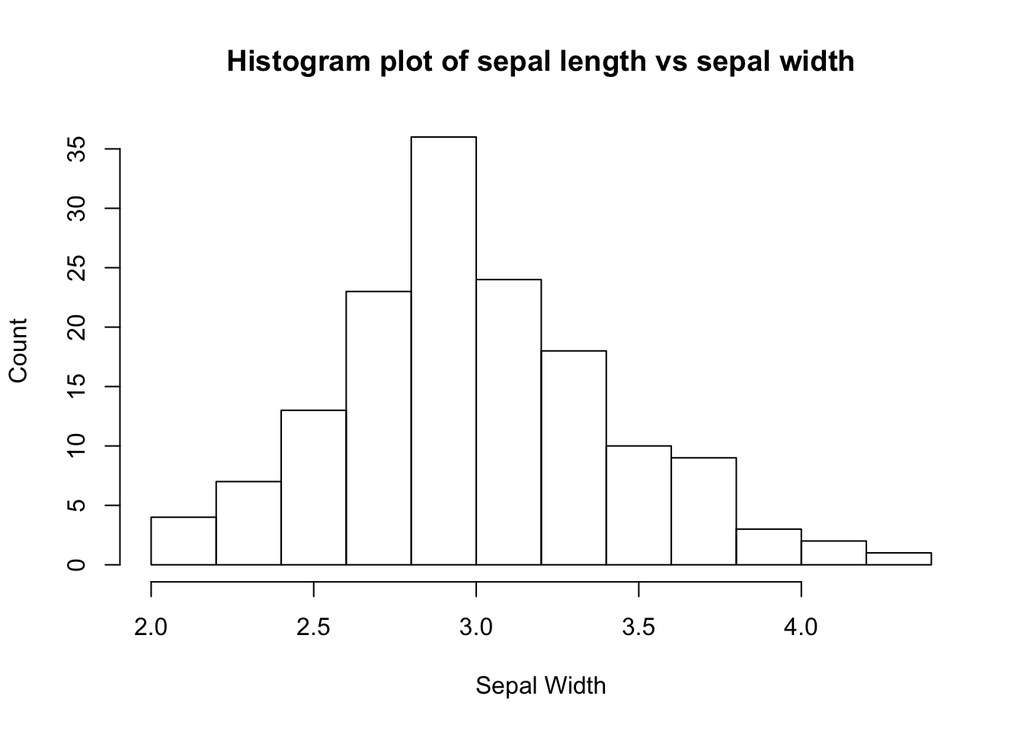

```r
hist(data$Sepal.Width,
     xlab='Sepal Width',ylab='Count',
     main= 'Histogram plot of sepal length vs sepal width')
```

We use the `plot` function to create a scatter plot of sepal length vs sepal width.

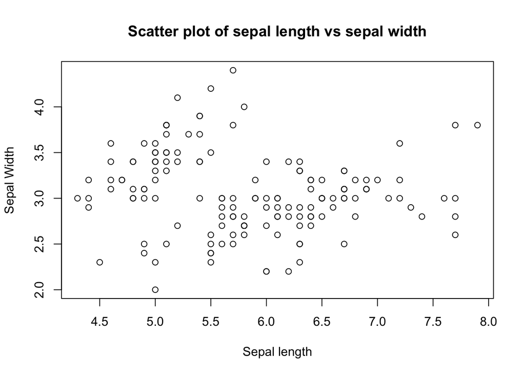

```r
plot(data$Sepal.Length, data$Sepal.Width,
     xlab='Sepal length', ylab='Sepal Width',
     main= 'Scatter plot of sepal length vs sepal width')
```

### Stacking plots (without ggplot2)

We also differentiate the scatter plot above by species. We plot each species separately. First, we call `plot` to create a canvas with an set of points associated with Setosa. If we were to call `plot` again, this would clear the previous plot. Rather, we call `points` to add scatter plots to existing plot. `points` does not clear the previous plot.

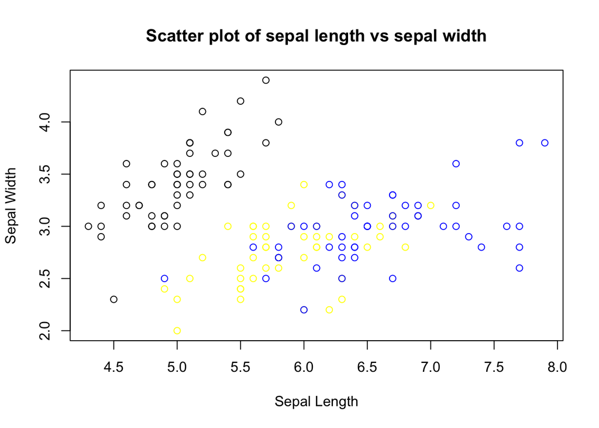

```r
plot(data[data$Species == "setosa", ]$Sepal.Length,
     data[data$Species == "setosa", ]$Sepal.Width,
     xlab = 'Sepal Length',  ylab= 'Sepal Width',
     xlim = range(as.matrix(data$Sepal.Length)),
     ylim = range(as.matrix(data$Sepal.Width)),
     main= 'Scatter plot of sepal length vs sepal width')

points(data[data$Species == "versicolor", ]$Sepal.Length,
       data[data$Species == "versicolor", ]$Sepal.Width,
       col = 'yellow')

points(data[data$Species == "virginica", ]$Sepal.Length,
       data[data$Species == "virginica", ]$Sepal.Width, col = 'blue')
```

### Scatter plot matrix

It is quite cumbersome to call to `plot` multiple times to create scatter plots for various pairs of explanatory variables.

There exists a convience function, `pairs`, that will create a matrix of scatter plots for all possible explanatory variable combination.

We give the `pairs` the first four columns of `data`. It will create a scatter plot matrix for sepal length, sepal width, petal length and petal width.

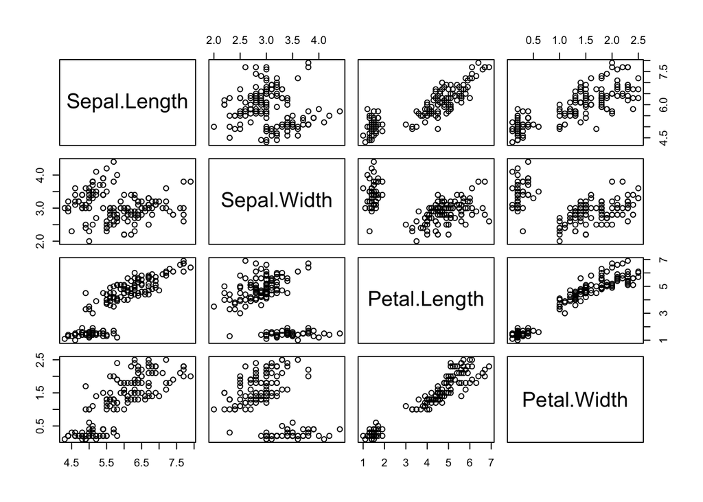

```r
pairs(data[,c(1:4)])
```

### Correlation matrix

From the scatter plot matrix above, we can see the qualitative correlation patterns between explanatory variables. We can also calculate these correlations explicitly and as a matrix using the `cor` function.

```r
cor(data[,c(1:4)])
```

```
##              Sepal.Length Sepal.Width Petal.Length Petal.Width
## Sepal.Length    1.0000000  -0.1175698    0.8717538   0.8179411
## Sepal.Width    -0.1175698   1.0000000   -0.4284401  -0.3661259
## Petal.Length    0.8717538  -0.4284401    1.0000000   0.9628654
## Petal.Width     0.8179411  -0.3661259    0.9628654   1.0000000
```

# Linear regression

Given a response variable, $y$, explanatory variables, $X_i$, and assuming that

$$y_i = \beta_0 +\beta_1 X_{1i} + \beta_2 X_{2i} + \cdots + \beta_n X_{ni} +\varepsilon$$

where $\varepsilon$ is a noise term, linear regression attempts the find the coefficients $\beta_i$ that makes $\varepsilon$ as small as possible.

The formula above assumes that response variable is a linear function explanatory variables. The noise term is added to account for the fact that most data is noisy and will not perfectly fit its ‘true’ function.

Linear regression also assumes that the noise is normally distributed with zero mean.

If these two assumptions are voilated then
$$r_i = y_i - \beta_0 +\beta_1 X_{1i} + \beta_2 X_{2i} + \cdots + \beta_n X_{ni}$$

## Linear regression syntax

To regress the response variable, `Sepal.Width`, with explanatory variables, `Sepal.Length`, `Species`, `Petal.Length` and `Petal.Width`, we use the `lm` function.

The first argument is `lm` is the formula. The name of the column of the response variable is written first. It is followed by a tilde, `~`. After the tilde, we write names of the explanatory variable each separated by a `+`. `1` can also be added to the formula to represent a constant term.

### General Syntax: Constant Term

First, I use the formula `Sepal.Width ~ 1`. This formula is equivalent to

$$\text{Sepal.Width} = \beta_0 + \varepsilon.$$

Note that constant term is simply the mean response variable.

```r
ols <- lm(Sepal.Width ~ 1, data = data)
summary(ols)
```

```
##
## Call:
## lm(formula = Sepal.Width ~ 1, data = data)
##
## Residuals:
##      Min       1Q   Median       3Q      Max
## -1.05733 -0.25733 -0.05733  0.24267  1.34267
##
## Coefficients:
##             Estimate Std. Error t value Pr(>|t|)
## (Intercept)  3.05733    0.03559   85.91   <2e-16 ***
## ---
## Signif. codes:  0 '***' 0.001 '**' 0.01 '*' 0.05 '.' 0.1 ' ' 1
##
## Residual standard error: 0.4359 on 149 degrees of freedom
```

```r
print(mean(data$Sepal.Width))
```

```
## [1] 3.057333
```

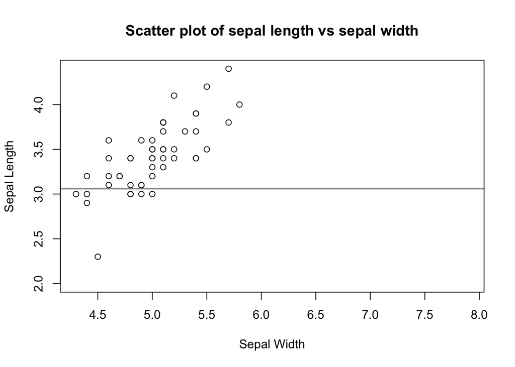

```r
plot(data[data$Species == "setosa", ]$Sepal.Length,
     data[data$Species == "setosa", ]$Sepal.Width,
     xlab = 'Sepal Width',  ylab= 'Sepal Length',
     xlim = range(as.matrix(data$Sepal.Length)),
     ylim = range(as.matrix(data$Sepal.Width)),
     main= 'Scatter plot of sepal length vs sepal width')

coefs = coef(ols)
abline(coefs[1],0)
```

### General Syntax: Explanatory Variable and Constant Term

I use then formula `Sepal.Width ~ 1 + Sepal.Length`. This formula is equivalent to

$$\text{Sepal.Width} = \beta_0 + \beta_1\text{Sepal.Length}+ \varepsilon$$

```r
ols <- lm(Sepal.Width ~ 1 + Sepal.Length, data = data)
summary(ols)
```

```
##
## Call:
## lm(formula = Sepal.Width ~ 1 + Sepal.Length, data = data)
##
## Residuals:
##     Min      1Q  Median      3Q     Max
## -1.1095 -0.2454 -0.0167  0.2763  1.3338
##
## Coefficients:
##              Estimate Std. Error t value Pr(>|t|)
## (Intercept)   3.41895    0.25356   13.48   <2e-16 ***
## Sepal.Length -0.06188    0.04297   -1.44    0.152
## ---
## Signif. codes:  0 '***' 0.001 '**' 0.01 '*' 0.05 '.' 0.1 ' ' 1
##
## Residual standard error: 0.4343 on 148 degrees of freedom
## Multiple R-squared:  0.01382,    Adjusted R-squared:  0.007159
## F-statistic: 2.074 on 1 and 148 DF,  p-value: 0.1519
```

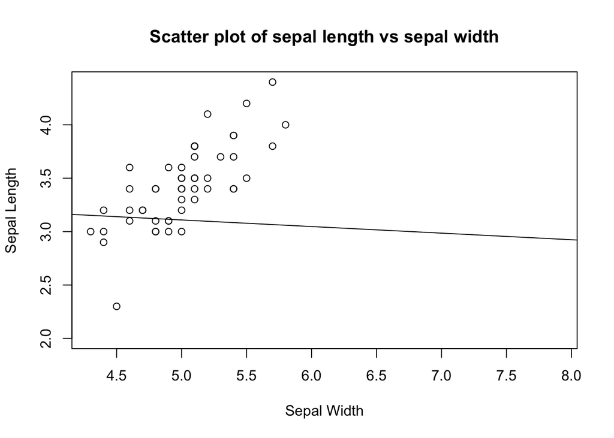

```r
plot(data[data$Species == "setosa", ]$Sepal.Length,
     data[data$Species == "setosa", ]$Sepal.Width,
     xlab = 'Sepal Width',  ylab= 'Sepal Length',
     xlim = range(as.matrix(data$Sepal.Length)),
     ylim = range(as.matrix(data$Sepal.Width)),
     main= 'Scatter plot of sepal length vs sepal width')

coefs = coef(ols)
abline(coefs[1],coefs[2])
```

### General Syntax: Factors

I use then formula `Sepal.Width ~ 1 + Sepal.Length + as.factor(Species)`. This formula is equivalent to

$$\text{Sepal.Width} = \beta_0 + \beta_1\text{Sepal.Length} + \beta_2 I(\text{Species} = \text{Veriscolor}) + \beta_3 I(\text{Species} = \text{Virginica}) + \varepsilon$$

```r
ols <- lm(Sepal.Width ~ 1 + Sepal.Length + as.factor(Species), data = data)
summary(ols)
```

```
##
## Call:
## lm(formula = Sepal.Width ~ 1 + Sepal.Length + as.factor(Species),
##     data = data)
##
## Residuals:
##      Min       1Q   Median       3Q      Max
## -0.95096 -0.16522  0.00171  0.18416  0.72918
##
## Coefficients:
##                              Estimate Std. Error t value Pr(>|t|)
## (Intercept)                   1.67650    0.23536   7.123 4.46e-11 ***
## Sepal.Length                  0.34988    0.04630   7.557 4.19e-12 ***
## as.factor(Species)versicolor -0.98339    0.07207 -13.644  < 2e-16 ***
## as.factor(Species)virginica  -1.00751    0.09331 -10.798  < 2e-16 ***
## ---
## Signif. codes:  0 '***' 0.001 '**' 0.01 '*' 0.05 '.' 0.1 ' ' 1
##
## Residual standard error: 0.289 on 146 degrees of freedom
## Multiple R-squared:  0.5693, Adjusted R-squared:  0.5604
## F-statistic: 64.32 on 3 and 146 DF,  p-value: < 2.2e-16
```

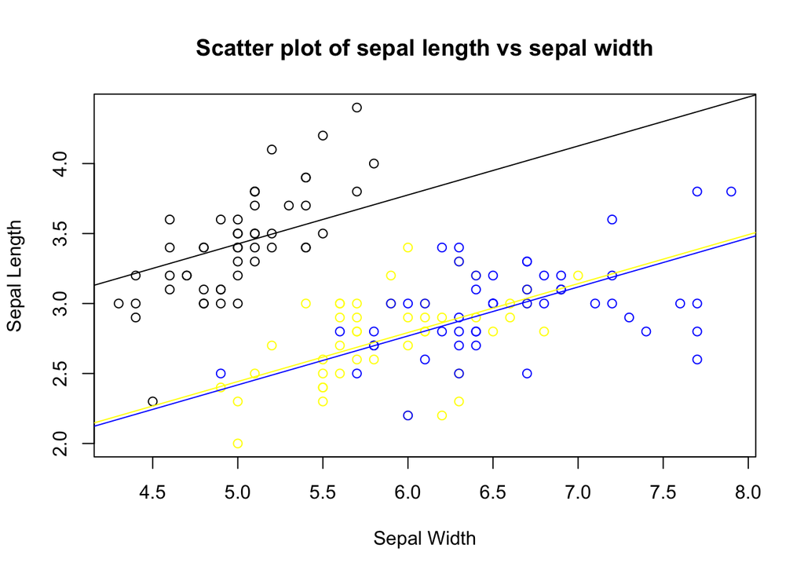

```r
plot(data[data$Species == "setosa", ]$Sepal.Length,
     data[data$Species == "setosa", ]$Sepal.Width,
     xlab = 'Sepal Width',  ylab= 'Sepal Length',
     xlim = range(as.matrix(data$Sepal.Length)),
     ylim = range(as.matrix(data$Sepal.Width)),
     main= 'Scatter plot of sepal length vs sepal width')

points(data[data$Species == "versicolor", ]$Sepal.Length,
       data[data$Species == "versicolor", ]$Sepal.Width,
       col = 'yellow')

points(data[data$Species == "virginica", ]$Sepal.Length,
       data[data$Species == "virginica", ]$Sepal.Width, col = 'blue')
coefs = coef(ols)
abline(coefs[1],coefs[2])
abline(coefs[3] + coefs[1],coefs[2],col='yellow')
abline(coefs[4] +coefs[1],coefs[2],col='blue')
```

### Advanced Syntax: Nonlinear Regression

The `lm` function can be extended to nonlinear functions. For example, it possible include a quadratic term in our model.

$$\text{Sepal.Width} = \beta_1\text{Sepal.Length} + \beta_2\text{Sepal.Length}^2 + \varepsilon$$

```r
ols_quadratic <- lm(Sepal.Width ~ Sepal.Length + I(Sepal.Length^2), data = data)
summary(ols_quadratic)
```

```
##
## Call:
## lm(formula = Sepal.Width ~ Sepal.Length + I(Sepal.Length^2),
##     data = data)
##
## Residuals:
##      Min       1Q   Median       3Q      Max
## -1.13070 -0.26310 -0.02446  0.25728  1.38725
##
## Coefficients:
##                   Estimate Std. Error t value Pr(>|t|)
## (Intercept)        6.41584    1.58499   4.048 8.33e-05 ***
## Sepal.Length      -1.08556    0.53625  -2.024   0.0447 *
## I(Sepal.Length^2)  0.08571    0.04476   1.915   0.0574 .
## ---
## Signif. codes:  0 '***' 0.001 '**' 0.01 '*' 0.05 '.' 0.1 ' ' 1
##
## Residual standard error: 0.4304 on 147 degrees of freedom
## Multiple R-squared:  0.03783,    Adjusted R-squared:  0.02474
## F-statistic:  2.89 on 2 and 147 DF,  p-value: 0.05877
```

It is also possible to include higher order nonlinear terms, such as cubic, quintic, etc.

### Advanced Syntax: Interaction term

It is also possible to include model interaction between explanatory variables.

$$\text{Sepal.Width} = \beta_1\text{Sepal.Length} + \beta_2\text{Petal.Length} + \beta_3 \text{Sepal.Length}\times\text{Petal.Length} + \varepsilon$$
$\text{Sepal.Length}\times\text{Petal.Length}$ models simple interaction between Sepal.Length and Petal.Length.

```r
ols_interaction <- lm(Sepal.Width ~ Sepal.Length + Petal.Length + Sepal.Length*Petal.Length, data = data)
summary(ols_interaction)
```

```
##
## Call:
## lm(formula = Sepal.Width ~ Sepal.Length + Petal.Length + Sepal.Length *
##     Petal.Length, data = data)
##
## Residuals:
##      Min       1Q   Median       3Q      Max
## -0.86960 -0.19846  0.00743  0.20704  0.72871
##
## Coefficients:
##                           Estimate Std. Error t value Pr(>|t|)
## (Intercept)                1.51011    0.64336   2.347 0.020257 *
## Sepal.Length               0.46940    0.12954   3.624 0.000400 ***
## Petal.Length              -0.42907    0.11832  -3.626 0.000397 ***
## Sepal.Length:Petal.Length  0.01795    0.02186   0.821 0.413063
## ---
## Signif. codes:  0 '***' 0.001 '**' 0.01 '*' 0.05 '.' 0.1 ' ' 1
##
## Residual standard error: 0.3239 on 146 degrees of freedom
## Multiple R-squared:  0.4589, Adjusted R-squared:  0.4478
## F-statistic: 41.28 on 3 and 146 DF,  p-value: < 2.2e-16
```

Note that using the formula `Sepal.Width ~ Sepal.Length*Petal.Length` produces the same result as `Sepal.Length + Petal.Length + Sepal.Length*Petal.Length`.

```r
ols_interaction <- lm(Sepal.Width ~ Sepal.Length*Petal.Length, data = data)
summary(ols_interaction)
```

```
##
## Call:
## lm(formula = Sepal.Width ~ Sepal.Length * Petal.Length, data = data)
##
## Residuals:
##      Min       1Q   Median       3Q      Max
## -0.86960 -0.19846  0.00743  0.20704  0.72871
##
## Coefficients:
##                           Estimate Std. Error t value Pr(>|t|)
## (Intercept)                1.51011    0.64336   2.347 0.020257 *
## Sepal.Length               0.46940    0.12954   3.624 0.000400 ***
## Petal.Length              -0.42907    0.11832  -3.626 0.000397 ***
## Sepal.Length:Petal.Length  0.01795    0.02186   0.821 0.413063
## ---
## Signif. codes:  0 '***' 0.001 '**' 0.01 '*' 0.05 '.' 0.1 ' ' 1
##
## Residual standard error: 0.3239 on 146 degrees of freedom
## Multiple R-squared:  0.4589, Adjusted R-squared:  0.4478
## F-statistic: 41.28 on 3 and 146 DF,  p-value: < 2.2e-16
```

### Advanced Syntax: Non-linear regression and Interaction term

```r
ols_q_i <- lm(Sepal.Width ~ Sepal.Length*as.factor(Species) + I(Sepal.Length^2), data = data)
summary(ols_q_i)
```

```
##
## Call:
## lm(formula = Sepal.Width ~ Sepal.Length * as.factor(Species) +
##     I(Sepal.Length^2), data = data)
##
## Residuals:
##      Min       1Q   Median       3Q      Max
## -0.71404 -0.15888  0.01535  0.16089  0.61676
##
## Coefficients:
##                                           Estimate Std. Error t value
## (Intercept)                               -2.17766    1.59715  -1.363
## Sepal.Length                               1.44156    0.60909   2.367
## as.factor(Species)versicolor               0.79275    0.93445   0.848
## as.factor(Species)virginica                0.84269    1.29009   0.653
## I(Sepal.Length^2)                         -0.06397    0.05959  -1.073
## Sepal.Length:as.factor(Species)versicolor -0.35909    0.17402  -2.064
## Sepal.Length:as.factor(Species)virginica  -0.36224    0.22839  -1.586
##                                           Pr(>|t|)
## (Intercept)                                 0.1749
## Sepal.Length                                0.0193 *
## as.factor(Species)versicolor                0.3977
## as.factor(Species)virginica                 0.5147
## I(Sepal.Length^2)                           0.2849
## Sepal.Length:as.factor(Species)versicolor   0.0409 *
## Sepal.Length:as.factor(Species)virginica    0.1149
## ---
## Signif. codes:  0 '***' 0.001 '**' 0.01 '*' 0.05 '.' 0.1 ' ' 1
##
## Residual standard error: 0.2722 on 143 degrees of freedom
## Multiple R-squared:  0.6257, Adjusted R-squared:   0.61
## F-statistic: 39.85 on 6 and 143 DF,  p-value: < 2.2e-16
```

## Obtaining the residuals

Recall it is possible the measure the error between the model and response variables. Given least squares fit,

It is possible to obtain residuals from the output of `lm`

```r
res <- ols$residuals
head(res)
```

```
##           1           2           3           4           5           6
##  0.03911127 -0.39091271 -0.12093668 -0.18594867  0.17409928  0.33414723
```

## Obtaining the fitted values

It is also possible to get predicted model values from the output of `lm`.

```r
pred <- ols$fitted.values
head(data.frame(pred=pred,orig=data$Sepal.Width ))
```

```
##       pred orig
## 1 3.460889  3.5
## 2 3.390913  3.0
## 3 3.320937  3.2
## 4 3.285949  3.1
## 5 3.425901  3.6
## 6 3.565853  3.9
```

## Obtaining the ANOVA table

```r
anova(ols)
```

```
## Analysis of Variance Table
##
## Response: Sepal.Width
##                     Df  Sum Sq Mean Sq F value  Pr(>F)
## Sepal.Length         1  0.3913  0.3913  4.6851 0.03205 *
## as.factor(Species)   2 15.7225  7.8613 94.1304 < 2e-16 ***
## Residuals          146 12.1931  0.0835
## ---
## Signif. codes:  0 '***' 0.001 '**' 0.01 '*' 0.05 '.' 0.1 ' ' 1
```

## Obtaining the variance-covariance matrix

```r
vcov(ols)
```

```
##                               (Intercept) Sepal.Length
## (Intercept)                   0.055394200 -0.010731903
## Sepal.Length                 -0.010731903  0.002143808
## as.factor(Species)versicolor  0.008310378 -0.001993742
## as.factor(Species)virginica   0.015307579 -0.003391504
##                              as.factor(Species)versicolor
## (Intercept)                                   0.008310378
## Sepal.Length                                 -0.001993742
## as.factor(Species)versicolor                  0.005194764
## as.factor(Species)virginica                   0.004824391
##                              as.factor(Species)virginica
## (Intercept)                                  0.015307579
## Sepal.Length                                -0.003391504
## as.factor(Species)versicolor                 0.004824391
## as.factor(Species)virginica                  0.008705945
```

## Obtaining confidence intervals for the coefficients

```r
confint(ols, level = 0.95)
```

```
##                                   2.5 %     97.5 %
## (Intercept)                   1.2113479  2.1416523
## Sepal.Length                  0.2583728  0.4413874
## as.factor(Species)versicolor -1.1258331 -0.8409440
## as.factor(Species)virginica  -1.1919146 -0.8231061
```

## Obtaining confidence interval of the mean response

```r
predict(ols, data.frame(Sepal.Length=4.0, Species="setosa"), interval="confidence", level = 0.95, se.fit=TRUE)
```

```
## $fit
##        fit      lwr      upr
## 1 3.076021 2.953552 3.198489
##
## $se.fit
## [1] 0.06196695
##
## $df
## [1] 146
##
## $residual.scale
## [1] 0.288989
```

## Obtaining prediction limits for new observation

```r
predict(ols, data.frame(Sepal.Length=4.0, Species="setosa"),  interval="prediction", level = 0.95, se.fit=TRUE)
```

```
## $fit
##        fit      lwr      upr
## 1 3.076021 2.491896 3.660145
##
## $se.fit
## [1] 0.06196695
##
## $df
## [1] 146
##
## $residual.scale
## [1] 0.288989
```

## Obtaining confidence band for the entire regression line

```r
alpha = 0.05
n = dim(iris)[1]
ci <- predict(ols, data.frame(Sepal.Length=4.0, Species="setosa"), interval="confidence", level= 1-alpha, se.fit=TRUE)
yh.hat <- ci$fit[1]
se.yh.hat <- ci$se.fit
w <- sqrt(2*qf(1-alpha, 2, n-2))
lower_bound <- yh.hat - w*se.yh.hat
upper_bound <- yh.hat + w*se.yh.hat
band <- c(lower_bound, upper_bound)
band
```

```
## [1] 2.922793 3.229248
```

## Standardized regression

```r
lm.beta(ols)
```

```
##
## Call:
## lm(formula = Sepal.Width ~ 1 + Sepal.Length + as.factor(Species),
##     data = data)
##
## Standardized Coefficients::
##                  (Intercept)                 Sepal.Length
##                    0.0000000                    0.6647082
## as.factor(Species)versicolor  as.factor(Species)virginica
##                   -1.0671319                   -1.0933079
```

# Model selection

## General linear test approach

```r
anova(ols_q_i, ols_interaction)
```

```
## Analysis of Variance Table
##
## Model 1: Sepal.Width ~ Sepal.Length * as.factor(Species) + I(Sepal.Length^2)
## Model 2: Sepal.Width ~ Sepal.Length * Petal.Length
##   Res.Df    RSS Df Sum of Sq      F    Pr(>F)
## 1    143 10.595
## 2    146 15.316 -3   -4.7219 21.245 1.939e-11 ***
## ---
## Signif. codes:  0 '***' 0.001 '**' 0.01 '*' 0.05 '.' 0.1 ' ' 1
```

```r
anova(ols_q_i, ols_quadratic)
```

```
## Analysis of Variance Table
##
## Model 1: Sepal.Width ~ Sepal.Length * as.factor(Species) + I(Sepal.Length^2)
## Model 2: Sepal.Width ~ Sepal.Length + I(Sepal.Length^2)
##   Res.Df    RSS Df Sum of Sq      F    Pr(>F)
## 1    143 10.595
## 2    147 27.236 -4   -16.642 56.155 < 2.2e-16 ***
## ---
## Signif. codes:  0 '***' 0.001 '**' 0.01 '*' 0.05 '.' 0.1 ' ' 1
```

```r
anova(ols_quadratic, ols)
```

```
## Analysis of Variance Table
##
## Model 1: Sepal.Width ~ Sepal.Length + I(Sepal.Length^2)
## Model 2: Sepal.Width ~ 1 + Sepal.Length + as.factor(Species)
##   Res.Df    RSS Df Sum of Sq      F    Pr(>F)
## 1    147 27.236
## 2    146 12.193  1    15.043 180.12 < 2.2e-16 ***
## ---
## Signif. codes:  0 '***' 0.001 '**' 0.01 '*' 0.05 '.' 0.1 ' ' 1
```

```r
anova(ols_interaction, ols)
```

```
## Analysis of Variance Table
##
## Model 1: Sepal.Width ~ Sepal.Length * Petal.Length
## Model 2: Sepal.Width ~ 1 + Sepal.Length + as.factor(Species)
##   Res.Df    RSS Df Sum of Sq F Pr(>F)
## 1    146 15.316
## 2    146 12.193  0    3.1234
```

## AIC, BIC, and Adjusted R2

```r
aic <- c(AIC(ols_quadratic), AIC(ols_interaction))
bic <- c(BIC(ols_quadratic), BIC(ols_interaction))
ar2 <- c(summary(ols_quadratic)$adj.r.squared, summary(ols_interaction)$adj.r.squared)
cbind(aic, bic, ar2)
```

```
##            aic      bic       ar2
## [1,] 177.76821 189.8107 0.0247357
## [2,]  93.42623 108.4794 0.4477939
```

## Step wise selection

```r
base <- lm(Sepal.Width ~ 1, data=data)
retailer_quadratic <- lm(Sepal.Width ~ . + I(Sepal.Length^2), data=data)
retailer_interaction <- lm(Sepal.Width ~ . + Sepal.Length*Species, data=data)
step_1 <- step(base, scope = list(upper=retailer_quadratic, lower= ~1), direction = "both", trace=TRUE)
```

```
## Start:  AIC=-248.13
## Sepal.Width ~ 1
##
##                     Df Sum of Sq    RSS     AIC
## + Species            2   11.3449 16.962 -320.95
## + Petal.Length       1    5.1960 23.111 -276.55
## + Petal.Width        1    3.7945 24.512 -267.72
## + Sepal.Length       1    0.3913 27.916 -248.22
## <none>                           28.307 -248.13
## + I(Sepal.Length^2)  1    0.3115 27.995 -247.79
##
## Step:  AIC=-320.95
## Sepal.Width ~ Species
##
##                     Df Sum of Sq    RSS     AIC
## + Sepal.Length       1    4.7689 12.193 -368.46
## + I(Sepal.Length^2)  1    4.1911 12.771 -361.52
## + Petal.Width        1    3.7554 13.207 -356.49
## + Petal.Length       1    2.4225 14.540 -342.07
## <none>                           16.962 -320.95
## - Species            2   11.3449 28.307 -248.13
##
## Step:  AIC=-368.46
## Sepal.Width ~ Species + Sepal.Length
##
##                     Df Sum of Sq    RSS     AIC
## + Petal.Width        1    1.5037 10.689 -386.21
## + I(Sepal.Length^2)  1    1.2775 10.916 -383.07
## <none>                           12.193 -368.46
## + Petal.Length       1    0.0210 12.172 -366.72
## - Sepal.Length       1    4.7689 16.962 -320.95
## - Species            2   15.7225 27.916 -248.22
##
## Step:  AIC=-386.21
## Sepal.Width ~ Species + Sepal.Length + Petal.Width
##
##                     Df Sum of Sq     RSS     AIC
## + I(Sepal.Length^2)  1    1.0942  9.5952 -400.41
## + Petal.Length       1    0.3619 10.3275 -389.37
## <none>                           10.6894 -386.21
## - Petal.Width        1    1.5037 12.1931 -368.46
## - Sepal.Length       1    2.5171 13.2066 -356.49
## - Species            2   10.9932 21.6826 -284.12
##
## Step:  AIC=-400.41
## Sepal.Width ~ Species + Sepal.Length + Petal.Width + I(Sepal.Length^2)
##
##                     Df Sum of Sq     RSS     AIC
## <none>                            9.5952 -400.41
## + Petal.Length       1    0.0648  9.5305 -399.42
## - I(Sepal.Length^2)  1    1.0942 10.6894 -386.21
## - Petal.Width        1    1.3204 10.9156 -383.07
## - Sepal.Length       1    1.4978 11.0931 -380.65
## - Species            2   12.0842 21.6794 -282.14
```

```r
step_2 <- step(base, scope = list(upper=retailer_interaction, lower= ~1), direction = "both", trace=TRUE)
```

```
## Start:  AIC=-248.13
## Sepal.Width ~ 1
##
##                Df Sum of Sq    RSS     AIC
## + Species       2   11.3449 16.962 -320.95
## + Petal.Length  1    5.1960 23.111 -276.55
## + Petal.Width   1    3.7945 24.512 -267.72
## + Sepal.Length  1    0.3913 27.916 -248.22
## <none>                      28.307 -248.13
##
## Step:  AIC=-320.95
## Sepal.Width ~ Species
##
##                Df Sum of Sq    RSS     AIC
## + Sepal.Length  1    4.7689 12.193 -368.46
## + Petal.Width   1    3.7554 13.207 -356.49
## + Petal.Length  1    2.4225 14.540 -342.07
## <none>                      16.962 -320.95
## - Species       2   11.3449 28.307 -248.13
##
## Step:  AIC=-368.46
## Sepal.Width ~ Species + Sepal.Length
##
##                        Df Sum of Sq    RSS     AIC
## + Petal.Width           1    1.5037 10.689 -386.21
## + Sepal.Length:Species  2    1.5132 10.680 -384.34
## <none>                              12.193 -368.46
## + Petal.Length          1    0.0210 12.172 -366.72
## - Sepal.Length          1    4.7689 16.962 -320.95
## - Species               2   15.7225 27.916 -248.22
##
## Step:  AIC=-386.21
## Sepal.Width ~ Species + Sepal.Length + Petal.Width
##
##                        Df Sum of Sq    RSS     AIC
## + Sepal.Length:Species  2    1.6924  8.997 -408.06
## + Petal.Length          1    0.3619 10.328 -389.37
## <none>                              10.689 -386.21
## - Petal.Width           1    1.5037 12.193 -368.46
## - Sepal.Length          1    2.5171 13.207 -356.49
## - Species               2   10.9932 21.683 -284.12
##
## Step:  AIC=-408.06
## Sepal.Width ~ Species + Sepal.Length + Petal.Width + Species:Sepal.Length
##
##                        Df Sum of Sq     RSS     AIC
## <none>                               8.9970 -408.06
## + Petal.Length          1   0.00785  8.9892 -406.19
## - Species:Sepal.Length  2   1.69237 10.6894 -386.21
## - Petal.Width           1   1.68292 10.6800 -384.34
```

```r
summary(step_1)
```

```
##
## Call:
## lm(formula = Sepal.Width ~ Species + Sepal.Length + Petal.Width +
##     I(Sepal.Length^2), data = data)
##
## Residuals:
##      Min       1Q   Median       3Q      Max
## -0.85363 -0.13206  0.00619  0.17297  0.78127
##
## Coefficients:
##                   Estimate Std. Error t value Pr(>|t|)
## (Intercept)       -2.60830    1.14098  -2.286   0.0237 *
## Speciesversicolor -1.59481    0.12661 -12.596  < 2e-16 ***
## Speciesvirginica  -1.88631    0.19275  -9.786  < 2e-16 ***
## Sepal.Length       1.80619    0.38096   4.741 5.05e-06 ***
## Petal.Width        0.49857    0.11200   4.451 1.70e-05 ***
## I(Sepal.Length^2) -0.12422    0.03065  -4.052 8.26e-05 ***
## ---
## Signif. codes:  0 '***' 0.001 '**' 0.01 '*' 0.05 '.' 0.1 ' ' 1
##
## Residual standard error: 0.2581 on 144 degrees of freedom
## Multiple R-squared:  0.661,  Adjusted R-squared:  0.6493
## F-statistic: 56.16 on 5 and 144 DF,  p-value: < 2.2e-16
```

```r
summary(step_2)
```

```
##
## Call:
## lm(formula = Sepal.Width ~ Species + Sepal.Length + Petal.Width +
##     Species:Sepal.Length, data = data)
##
## Residuals:
##      Min       1Q   Median       3Q      Max
## -0.77834 -0.14765  0.02457  0.16428  0.62667
##
## Coefficients:
##                                Estimate Std. Error t value Pr(>|t|)
## (Intercept)                     -0.4731     0.5105  -0.927   0.3556
## Speciesversicolor                1.2981     0.6573   1.975   0.0502 .
## Speciesvirginica                 1.2252     0.6501   1.884   0.0615 .
## Sepal.Length                     0.7515     0.1021   7.363 1.31e-11 ***
## Petal.Width                      0.5662     0.1095   5.172 7.68e-07 ***
## Speciesversicolor:Sepal.Length  -0.5503     0.1239  -4.442 1.77e-05 ***
## Speciesvirginica:Sepal.Length   -0.5883     0.1163  -5.058 1.28e-06 ***
## ---
## Signif. codes:  0 '***' 0.001 '**' 0.01 '*' 0.05 '.' 0.1 ' ' 1
##
## Residual standard error: 0.2508 on 143 degrees of freedom
## Multiple R-squared:  0.6822, Adjusted R-squared:  0.6688
## F-statistic: 51.15 on 6 and 143 DF,  p-value: < 2.2e-16
```

# Diagnostics

## Test for lack of fit

```r
full <- lm(Sepal.Width ~ as.factor(Sepal.Length)*as.factor(I(Sepal.Length^2))*as.factor(Species), data=data)
anova(ols_quadratic, full)
```

```
## Analysis of Variance Table
##
## Model 1: Sepal.Width ~ Sepal.Length + I(Sepal.Length^2)
## Model 2: Sepal.Width ~ as.factor(Sepal.Length) * as.factor(I(Sepal.Length^2)) *
##     as.factor(Species)
##   Res.Df     RSS Df Sum of Sq      F    Pr(>F)
## 1    147 27.2362
## 2     93  7.0068 54    20.229 4.9723 7.092e-12 ***
## ---
## Signif. codes:  0 '***' 0.001 '**' 0.01 '*' 0.05 '.' 0.1 ' ' 1
```

## Normal probability plot

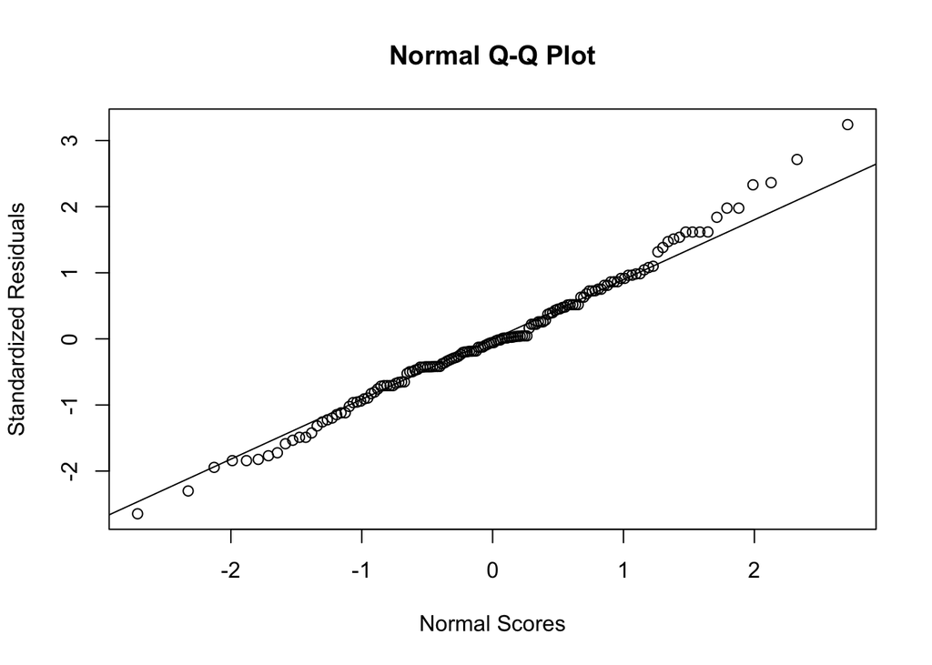

```r
std_res <- rstandard(ols_quadratic)
qqnorm(std_res,
     ylab="Standardized Residuals",
     xlab="Normal Scores")
qqline(std_res)
```

## Residual plots

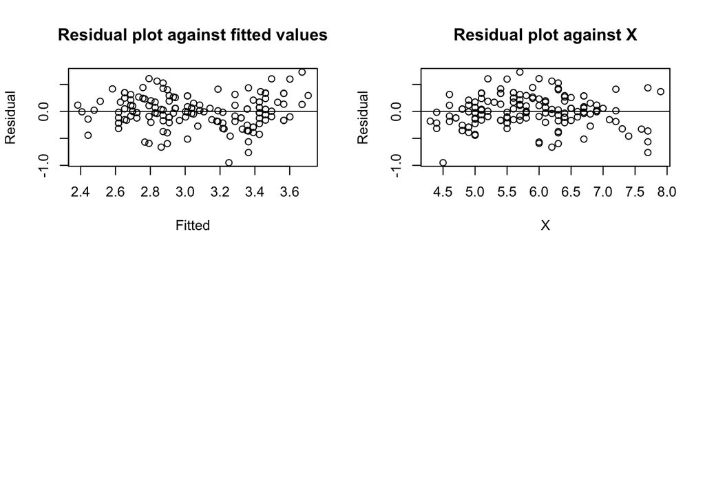

```r
par(mfrow=c(2,2))
plot(res ~ pred, xlab="Fitted", ylab="Residual", main="Residual plot against fitted values")
abline(h=0)
plot(res ~ data$Sepal.Length, xlab="X", ylab="Residual", main="Residual plot against X")
abline(h=0)
```

## Test for multicollinearity

See also function vif() in package “car”

```r
VIF <- rep(0,2)
VIF[1] <- 1/(1-summary(lm(Sepal.Width ~ Sepal.Length, data = data))$r.squared)
VIF[2] <- 1/(1-summary(lm(Sepal.Width ~ as.factor(Species), data = data))$r.squared)
VIF
```

```
## [1] 1.014016 1.668844
```

## Test for heteroskedasticity

```r
bptest(ols_quadratic, studentize = FALSE)
```

```
##
##  Breusch-Pagan test
##
## data:  ols_quadratic
## BP = 6.2857, df = 2, p-value = 0.04316
```

## Test for outlying Y observations–studentized deleted residual

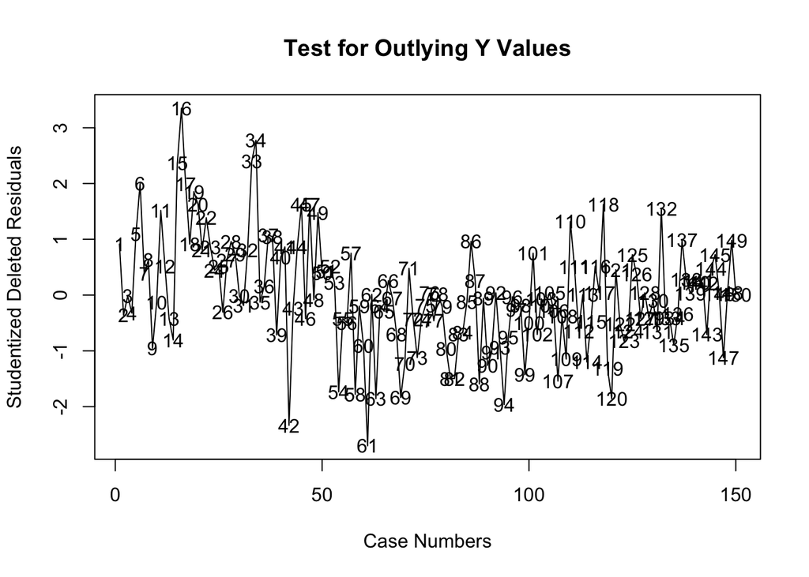

```r
p <- 5 # numer of parameters
case <- c(1:n) # n defined above
plot(case, rstudent(ols_quadratic), type="l", xlab="Case Numbers",
     ylab="Studentized Deleted Residuals", main="Test for Outlying Y Values")
text(case, rstudent(ols_quadratic), case)
```

```r
alpha <- 0.05
crit <- qt(1-alpha/2/n, n-p-1)
which(abs(rstudent(ols_quadratic)) >=crit ) # Here there's no evidence of outlying Y observations
```

```
## named integer(0)
```

## Test for outlying X observations–hat matrix leverage values

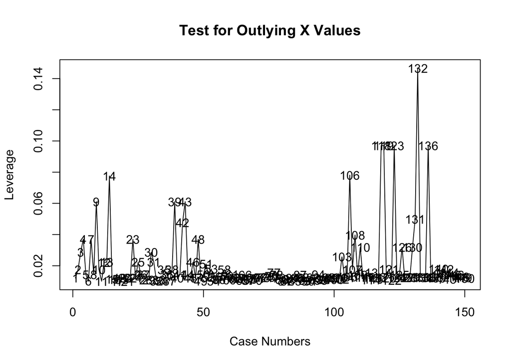

```r
leverage <- hatvalues(ols_quadratic)
plot(case, leverage, type="l", xlab="Case Numbers",
     ylab="Leverage", main="Test for Outlying X Values")
text(case, leverage, case)
abline(h=0.5, col=2)
```

```r
X_out <- which(leverage>0.5)
leverage[X_out] # Here there's no outlying X observations
```

```
## named numeric(0)
```

## Tests for influential observations

### Cook’s distance

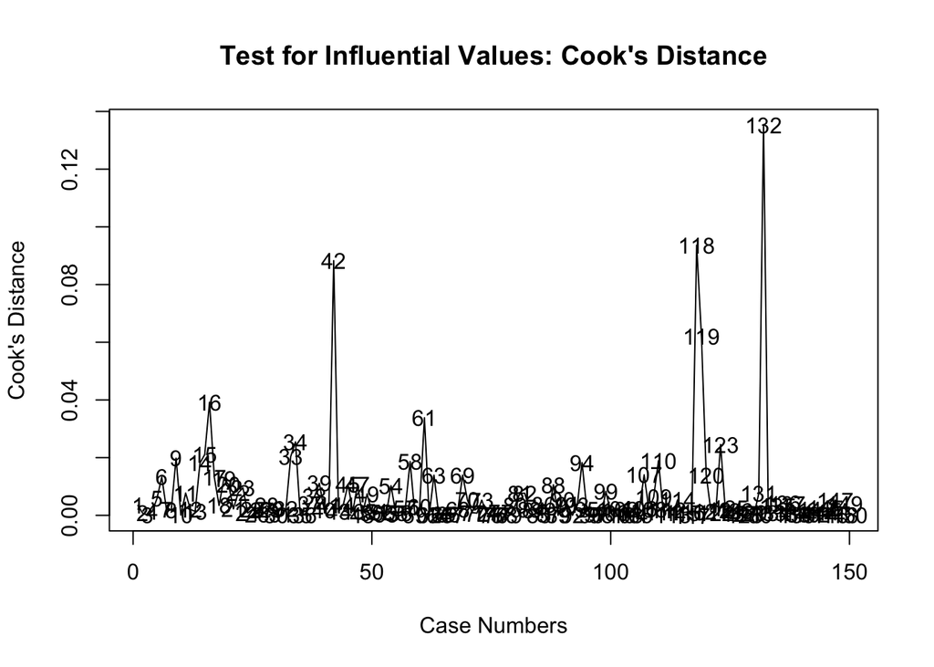

```r
plot(case, cooks.distance(ols_quadratic), type="l", xlab="Case Numbers",
     ylab="Cook's Distance", main = "Test for Influential Values: Cook's Distance")
text(case, cooks.distance(ols_quadratic))
```

```r
inf_obs <- which(cooks.distance(ols_quadratic)>0.5)
inf_obs
```

```
## named integer(0)
```

### DFFITS

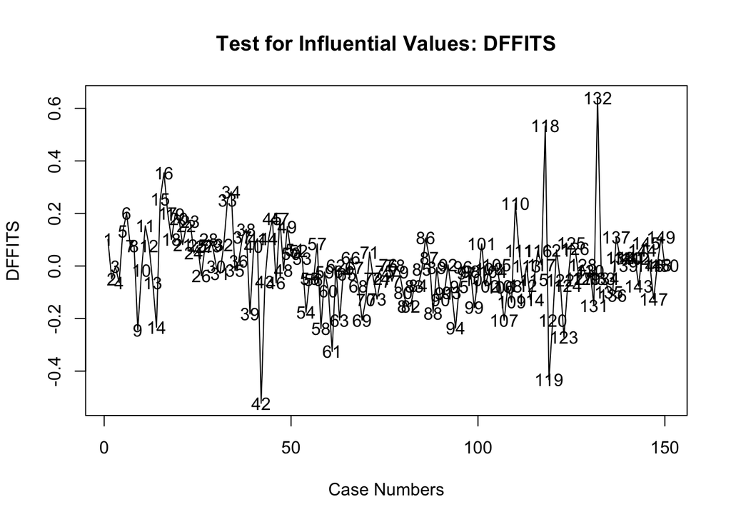

```r
plot(case, dffits(ols_quadratic), type="l", xlab="Case Numbers",
     ylab="DFFITS", main = "Test for Influential Values: DFFITS")
text(case, dffits(ols_quadratic))
```

```r
inf_obs2 <- which(abs(dffits(ols_quadratic))>2/sqrt(p/n))
inf_obs2
```

```
## named integer(0)
```

### DFBETAS

```r
inf_obs3 <- which(abs(dfbeta(ols_quadratic))>2/sqrt(n))
inf_obs3
```

```
##  [1]   9  14  15  16  19  23  34  39  42  58  61  63  69  88 118 119 120
## [18] 123 132 192 268 269 282
```